# project

<h1 id="%F0%9F%93%8A-Pr.-1">**📊 Pr. 1**</h1><hr />

<p>**Title:** Mall Customer Segmentation</p> <p>**Duration:** 6 Hours</p> <hr />

<h2 id="%F0%9F%93%9A-Download-and-Import-Modules">**📚 Download and Import Modules**</h2>

```python
import pandas as pd
import numpy as np
import matplotlib.pyplot as plt
import seaborn as sns
from kneed import KneeLocator
from sklearn.preprocessing import LabelEncoder, StandardScaler
from sklearn.cluster import KMeans, AgglomerativeClustering, DBSCAN
from sklearn.metrics import (
    silhouette_score,
    davies_bouldin_score,
    calinski_harabasz_score
)
from sklearn.neighbors import NearestNeighbors
from scipy.cluster.hierarchy import dendrogram, linkage
```

<hr />

<h2 id="%F0%9F%97%82%EF%B8%8F-Dataset">**🗂️ Dataset**</h2><p>This project uses the Mall Customer Segmentation Dataset published on Kaggle. It contains 200 anonymised customer records collected from a shopping mall, with features covering demographic attributes and spending behaviour. Its small, clean structure makes it ideal for exploring all three unsupervised learning algorithms — K-Means, Agglomerative Hierarchical Clustering, and DBSCAN — side-by-side, without the distraction of heavy preprocessing.</p>

<hr />

<h2 id="%F0%9F%93%9D-Tasks">**📝 Tasks**</h2>

<h3 id="Task-1:-Data-Loading-&-Exploratory-Data-Analysis-(EDA)">Task 1: Data Loading & Exploratory Data Analysis (EDA)</h3> <thead> <th>#</th> <th>Action</th> <th>Details / Configuration</th> </thead> <tbody> </tbody>

[output not shown]

```python
df = pd.read_csv('data/Mall_Customers.csv')

display(df.head())
```

<style scoped> .dataframe tbody tr th:only-of-type { vertical-align: middle; } .dataframe tbody tr th { vertical-align: top; } .dataframe thead th { text-align: right; } </style> <thead> <th></th> <th>CustomerID</th> <th>Gender</th> <th>Age</th> <th>Annual Income (k$)</th> <th>Spending Score (1-100)</th> </thead> <tbody> <th>0</th> <th>1</th> <th>2</th> <th>3</th> <th>4</th> </tbody>

| 1 | Male | 19 | 15 | 39 |
| --- | --- | --- | --- | --- |
| 2 | Male | 21 | 15 | 81 |
| 3 | Female | 20 | 16 | 6 |
| 4 | Female | 23 | 16 | 77 |
| 5 | Female | 31 | 17 | 40 |

```python
df = df.drop(columns=['CustomerID'])

columns_rename_map = {
    'Annual Income (k$)': 'Annual_Income',
    'Spending Score (1-100)': 'Spending_Score'
}

df = df.rename(columns=columns_rename_map)
```

```python
df.info()
```

```
<class 'pandas.core.frame.DataFrame'>
RangeIndex: 200 entries, 0 to 199
Data columns (total 4 columns):
 #   Column          Non-Null Count  Dtype
---  ------          --------------  -----
 0   Gender          200 non-null    object
 1   Age             200 non-null    int64
 2   Annual_Income   200 non-null    int64
 3   Spending_Score  200 non-null    int64
dtypes: int64(3), object(1)
memory usage: 6.4+ KB
```

```python
gender_encoder = LabelEncoder()
df['Gender'] = gender_encoder.fit_transform(df['Gender'])

display(df.head())
```

<style scoped> .dataframe tbody tr th:only-of-type { vertical-align: middle; } .dataframe tbody tr th { vertical-align: top; } .dataframe thead th { text-align: right; } </style> <thead> <th></th> <th>Gender</th> <th>Age</th> <th>Annual_Income</th> <th>Spending_Score</th> </thead> <tbody> <th>0</th> <th>1</th> <th>2</th> <th>3</th> <th>4</th> </tbody>

| 1 | 19 | 15 | 39 |
| --- | --- | --- | --- |
| 1 | 21 | 15 | 81 |
| 0 | 20 | 16 | 6 |
| 0 | 23 | 16 | 77 |
| 0 | 31 | 17 | 40 |

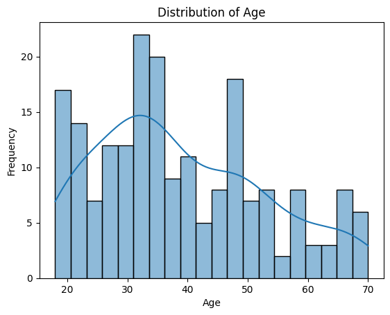

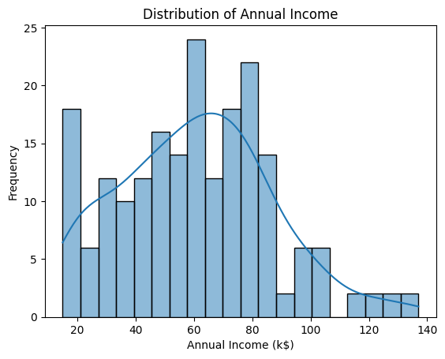

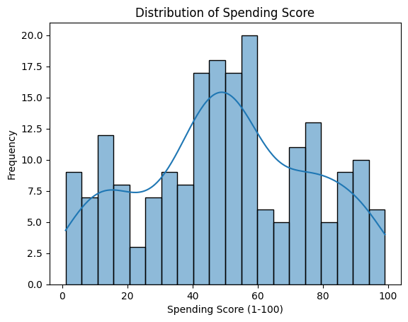

```python
sns.histplot(data=df, x='Age', bins=20, kde=True)
plt.title('Distribution of Age')
plt.xlabel('Age')
plt.ylabel('Frequency')
plt.show()

sns.histplot(data=df, x='Annual_Income', bins=20, kde=True)
plt.title('Distribution of Annual Income')
plt.xlabel('Annual Income (k$)')
plt.ylabel('Frequency')
plt.show()

sns.histplot(data=df, x='Spending_Score', bins=20, kde=True)
plt.title('Distribution of Spending Score')
plt.xlabel('Spending Score (1-100)')
plt.ylabel('Frequency')
plt.show()
```

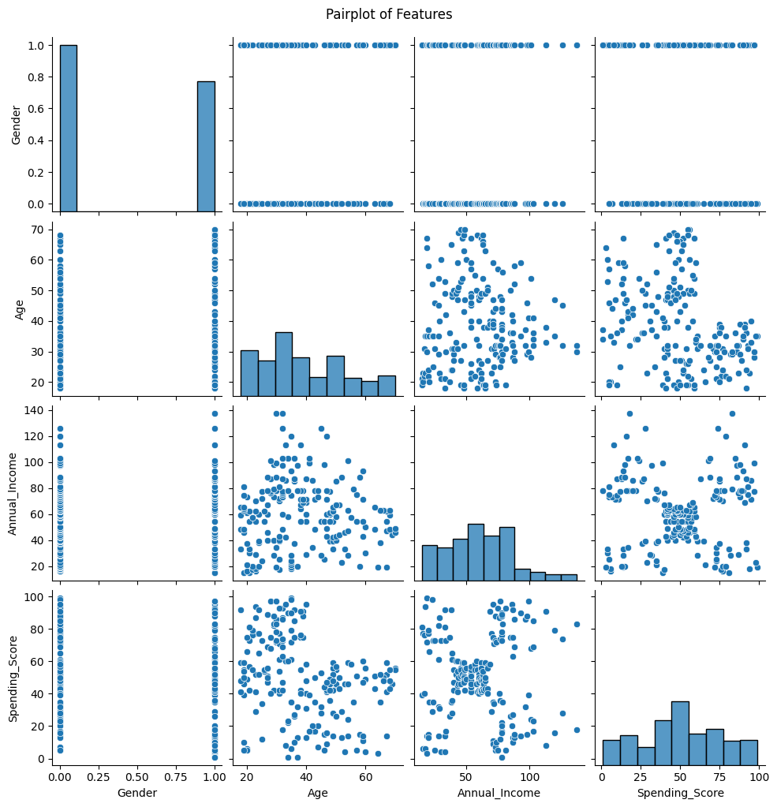

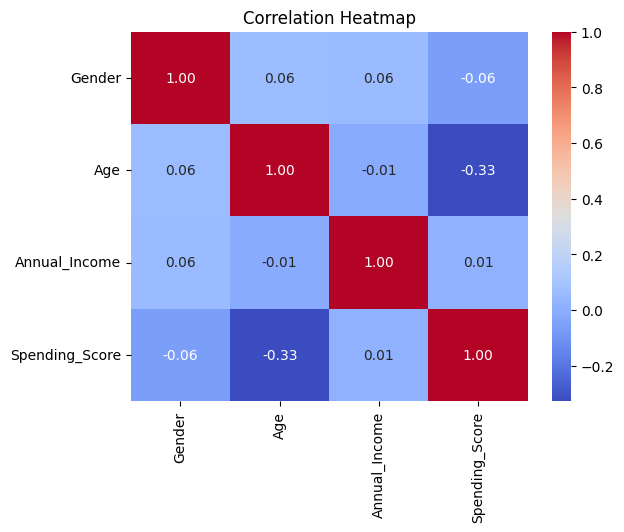

```python
sns.pairplot(data=df)
plt.suptitle('Pairplot of Features', y=1.02)
plt.show()

sns.heatmap(df.corr(), annot=True, cmap='coolwarm', fmt='.2f')
plt.title('Correlation Heatmap')
plt.show()
```

- **Clustering Observations:** The pairplot shows potential natural clusters, especially when looking at the relationship between income and spending habits.
- **Correlation Analysis:** Most features show low to moderate linear correlation, suggesting that clustering will rely on multidimensional patterns rather than simple linear relationships.
- **Optimal Visualization Pair:** `Annual_Income` and `Spending_Score` are likely the most informative features for visual separation, as they tend to create distinct, interpretable customer segments (e.g., "High Earners, Low Spenders").

<hr />

<h3 id="Task-2:-Feature-Scaling-&-Feature-Selection">**Task 2: Feature Scaling & Feature Selection**</h3> <thead> <th>#</th> <th>Action</th> <th>Details / Configuration</th> </thead> <tbody> </tbody>

[output not shown]

```python
scaler = StandardScaler()
scaled_features = scaler.fit_transform(df[['Age', 'Annual_Income', 'Spending_Score']])
df_scaled = df.copy()
df_scaled[['Age', 'Annual_Income', 'Spending_Score']] = scaled_features
```

```python
df_2f = df_scaled[['Annual_Income', 'Spending_Score']]
```

<h5 id="Why-use-StandardScaler-before-clustering?">**Why use `StandardScaler` before clustering?**</h5><p>Distance-based algorithms like **K-Means** and **DBSCAN** are highly sensitive to the magnitude of features. Because they rely on calculating Euclidean distances between points, features with larger numerical ranges will disproportionately influence the model.</p> <p>For example, without scaling, `Annual_Income` (ranging from ~15 to 137) would dominate the distance calculations compared to `Spending_Score` (ranging from 1 to 100), effectively skewing the cluster formation. `StandardScaler` ensures all features contribute equally by centering them around a mean of 0 with a standard deviation of 1.</p> <hr />

<h3 id="Task-3:-K-Means-Clustering">**Task 3: K-Means Clustering**</h3> <thead> <th>#</th> <th>Action</th> <th>Details / Configuration</th> </thead> <tbody> </tbody>

[output not shown]

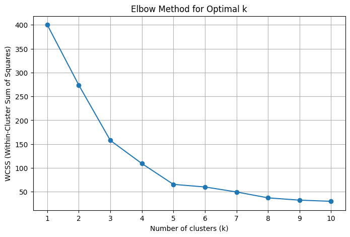

```
For n_clusters = 2, the average silhouette_score is : 0.3973
For n_clusters = 3, the average silhouette_score is : 0.4666
For n_clusters = 4, the average silhouette_score is : 0.4943
For n_clusters = 5, the average silhouette_score is : 0.5547
For n_clusters = 6, the average silhouette_score is : 0.5138
For n_clusters = 7, the average silhouette_score is : 0.5020
For n_clusters = 8, the average silhouette_score is : 0.4550
For n_clusters = 9, the average silhouette_score is : 0.4567
For n_clusters = 10, the average silhouette_score is : 0.4448
```

```python
from sklearn.metrics import silhouette_score as calculate_silhouette_score

wcss = []

for k in range(1, 11):
    kmeans = KMeans(n_clusters=k, random_state=42)
    kmeans.fit(df_2f)
    wcss.append(kmeans.inertia_)

plt.figure(figsize=(8, 5))
plt.plot(range(1, 11), wcss, marker='o')
plt.title('Elbow Method for Optimal k')
plt.xlabel('Number of clusters (k)')
plt.ylabel('WCSS (Within-Cluster Sum of Squares)')
plt.xticks(range(1, 11))
plt.grid()
plt.show()

for score in range(2, 11):
    kmeans = KMeans(n_clusters=score, random_state=42)
    cluster_labels = kmeans.fit_predict(df_2f)
    silhouette_avg = calculate_silhouette_score(df_2f, cluster_labels)
    print(f"For n_clusters = {score}, the average silhouette_score is : {silhouette_avg:.4f}")
```

```python
def find_optimal_k(wcss):
    """Function to find the optimal number of clusters using the elbow method."""
    kneedle = KneeLocator(range(1, 11), wcss, curve='convex', direction='decreasing')
    return kneedle.knee

k = find_optimal_k(wcss)
kmeans = KMeans(n_clusters=k, random_state=42)
kmeans.fit(df_2f)

df_clustered_kmeans = df.copy()
df_clustered_kmeans['Cluster'] = kmeans.labels_

print(f"Optimal number of clusters: {k}")

print("Clustering completed.")
print(df_clustered_kmeans.groupby('Cluster').mean())

print(f"Silhouette Score: {silhouette_score(df_2f, kmeans.labels_):.4f}")
```

```
Optimal number of clusters: 5
Clustering completed.
           Gender        Age  Annual_Income  Spending_Score
Cluster
0        0.407407  42.716049      55.296296       49.518519
1        0.461538  32.692308      86.538462       82.128205
2        0.409091  25.272727      25.727273       79.363636
3        0.542857  41.114286      88.200000       17.114286
4        0.391304  45.217391      26.304348       20.913043
Silhouette Score: 0.5547
```

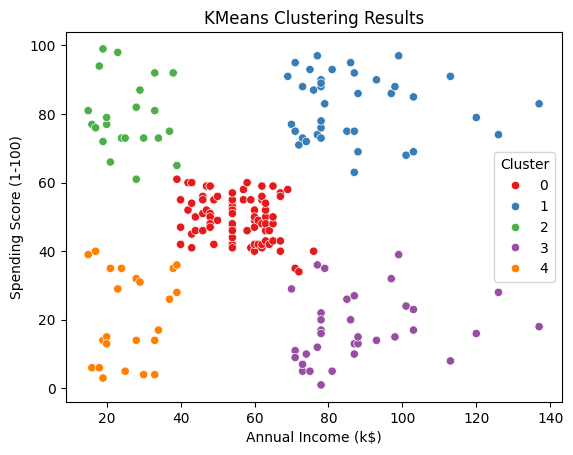

```python
sns.scatterplot(data=df_clustered_kmeans, x='Annual_Income', y='Spending_Score', hue='Cluster', palette='Set1')
plt.title('KMeans Clustering Results')
plt.xlabel('Annual Income (k$)')
plt.ylabel('Spending Score (1-100)')
plt.show()
```

```python
df_clustered_kmeans.groupby('Cluster')[['Age','Annual_Income','Spending_Score']].mean()
```

<style scoped> .dataframe tbody tr th:only-of-type { vertical-align: middle; } .dataframe tbody tr th { vertical-align: top; } .dataframe thead th { text-align: right; } </style> <thead> <th></th> <th>Age</th> <th>Annual_Income</th> <th>Spending_Score</th> <th>Cluster</th> <th></th> <th></th> <th></th> </thead> <tbody> <th>0</th> <th>1</th> <th>2</th> <th>3</th> <th>4</th> </tbody>

| 42.716049 | 55.296296 | 49.518519 |
| --- | --- | --- |
| 32.692308 | 86.538462 | 82.128205 |
| 25.272727 | 25.727273 | 79.363636 |
| 41.114286 | 88.200000 | 17.114286 |
| 45.217391 | 26.304348 | 20.913043 |

<h4 id="Cluster-Segmentation-Analysis">**Cluster Segmentation Analysis**</h4><p>Based on the K-Means clustering results, I have identified five distinct customer segments. Here is a breakdown of their profiles and the recommended marketing implications for the mall:</p> <thead> <th style="text-align:left">Cluster</th> <th style="text-align:left">Segment Name</th> <th style="text-align:left">Profile Summary</th> <th style="text-align:left">Business Implication / Marketing Strategy</th> </thead> <tbody> </tbody>

| **1** | **High Income, High Spenders** | High annual income and high spending score. | **Target Segment:** Focus on premium/luxury brands, exclusive loyalty rewards, and high-end customer service to maintain engagement. |
| --- | --- | --- | --- |
| **2** | **Low Income, High Spenders** | Low annual income but high spending score. | **Trendsetters:** Likely younger, impulse-driven shoppers. Use social media campaigns, trending products, and flash sales to capture their attention. |
| **0** | **Middle Income, Middle Spenders** | Moderate income and moderate spending score. | **Stable Segment:** Focus on consistent value, reliable quality, and seasonal promotional offers to encourage steady shopping. |
| **3** | **High Income, Low Spenders** | High annual income but low spending score. | **Potential Growth:** They have high purchasing power but aren't spending much at the mall. Use personalized, high-value offers or concierge services to attract them. |
| **4** | **Low Income, Low Spenders** | Low annual income and low spending score. | **Budget-Conscious:** Highly price-sensitive. Focus on essential goods, discount-led promotions, and budget-friendly brand partnerships. |

<hr />

<h3 id="Task-4:-Agglomerative-Hierarchical-Clustering">**Task 4: Agglomerative Hierarchical Clustering**</h3> <thead> <th>#</th> <th>Action</th> <th>Details / Configuration</th> </thead> <tbody> </tbody>

[output not shown]

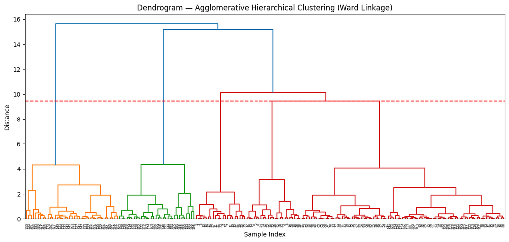

```python
# Compute linkage using Ward's method
Z = linkage(df_2f, method='ward')

# Plot dendrogram
plt.figure(figsize=(14, 6))
dendrogram(Z)
plt.title('Dendrogram — Agglomerative Hierarchical Clustering (Ward Linkage)')
plt.xlabel('Sample Index')
plt.ylabel('Distance')

# To indicate the optimal cut for 5 clusters, we find the height
# of the (N-k) merge. For N=200, k=5, it's the 195th merge (index 195).
# The merges are in Z[0:N-1, :]. The height of the merge that results in k clusters
# is the height of the (N-k)-th merge.
# Since we want 5 clusters, we want to cut above the 4th merge from the top.
# The last merge is index N-2.
# The 4th merge from the top is index (N-2) - 3 = N-5.
# For N=200, index is 195.
n_samples = df_2f.shape[0]
k_target = 5
cut_height = Z[n_samples - k_target, 2]
plt.axhline(y=cut_height, color='r', linestyle='--')

plt.show()
```

<h4 id="How-to-Read-the-Dendrogram">**How to Read the Dendrogram**</h4>

- **Ward Linkage:** This method minimizes the variance within each cluster. It merges clusters that result in the smallest increase in total within-cluster sum of squares.
- **The Dendrogram:** Each vertical line represents a cluster, and the height of the horizontal line (the merge) indicates the distance between the clusters being joined.
- **Choosing K:** By drawing a horizontal line (the red dashed line) through the dendrogram, the number of vertical lines intersected tells us the number of clusters. The red line is placed at a height that yields 5 clusters, which aligns with our K-Means results.

```python
# Fit Agglomerative Clustering
hierarchical = AgglomerativeClustering(n_clusters=5, linkage='ward')
hier_labels = hierarchical.fit_predict(df_2f)

# Add labels to the original df
df['Hier_Cluster'] = hier_labels
```

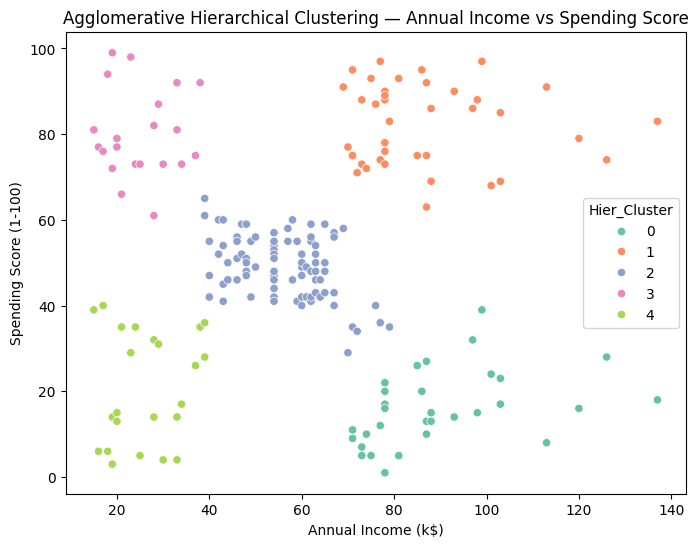

```python
plt.figure(figsize=(8, 6))
sns.scatterplot(x='Annual_Income', y='Spending_Score', hue='Hier_Cluster', data=df, palette='Set2')
plt.title('Agglomerative Hierarchical Clustering — Annual Income vs Spending Score')
plt.xlabel('Annual Income (k$)')
plt.ylabel('Spending Score (1-100)')
plt.show()
```

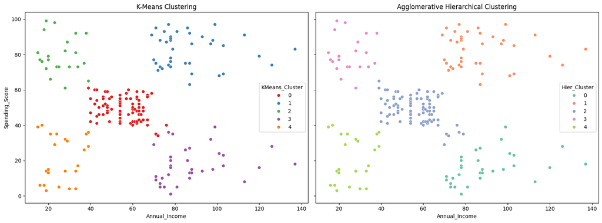

```python
# Ensure df has the KMeans labels from Task 3
# Note: We use the 'kmeans' object which was defined in Task 3.3
df['KMeans_Cluster'] = kmeans.labels_

# Side-by-side comparison
fig, (ax1, ax2) = plt.subplots(1, 2, figsize=(16, 6), sharex=True, sharey=True)

# K-Means plot
sns.scatterplot(x='Annual_Income', y='Spending_Score', hue='KMeans_Cluster', data=df, palette='Set1', ax=ax1)
ax1.set_title('K-Means Clustering')

# Hierarchical plot
sns.scatterplot(x='Annual_Income', y='Spending_Score', hue='Hier_Cluster', data=df, palette='Set2', ax=ax2)
ax2.set_title('Agglomerative Hierarchical Clustering')

plt.tight_layout()
plt.show()
```

<h4 id="Comparison:-K-Means-vs.-Hierarchical-Clustering">**Comparison: K-Means vs. Hierarchical Clustering**</h4>

- **Cluster Boundaries:** Comparing the two plots, the cluster boundaries are largely consistent, especially in the clearly separated high-income/high-spending and low-income/low-spending regions.
- **Differences:** Differences may appear at the borders where clusters overlap. K-Means, being centroid-based, assigns points to the nearest center, creating Voronoi-like partitions. Agglomerative clustering, being connectivity-based, might create slightly different shapes depending on the linkage (Ward minimizes variance, making it similar to K-Means but with a different hierarchical construction).
- **Conclusion:** Both algorithms successfully identified the same 5 main customer segments, confirming the robustness of the underlying data structure.

```python
hier_profile = df.groupby('Hier_Cluster')[['Age','Annual_Income','Spending_Score']].mean()
display(hier_profile)
```

<style scoped> .dataframe tbody tr th:only-of-type { vertical-align: middle; } .dataframe tbody tr th { vertical-align: top; } .dataframe thead th { text-align: right; } </style> <thead> <th></th> <th>Age</th> <th>Annual_Income</th> <th>Spending_Score</th> <th>Hier_Cluster</th> <th></th> <th></th> <th></th> </thead> <tbody> <th>0</th> <th>1</th> <th>2</th> <th>3</th> <th>4</th> </tbody>

| 41.000000 | 89.406250 | 15.593750 |
| --- | --- | --- |
| 32.692308 | 86.538462 | 82.128205 |
| 42.482353 | 55.811765 | 49.129412 |
| 25.333333 | 25.095238 | 80.047619 |
| 45.217391 | 26.304348 | 20.913043 |

<hr />

<h3 id="Task-5:-DBSCAN-Clustering">**Task 5: DBSCAN Clustering**</h3> <thead> <th>#</th> <th>Action</th> <th>Details / Configuration</th> </thead> <tbody> </tbody>

[output not shown]

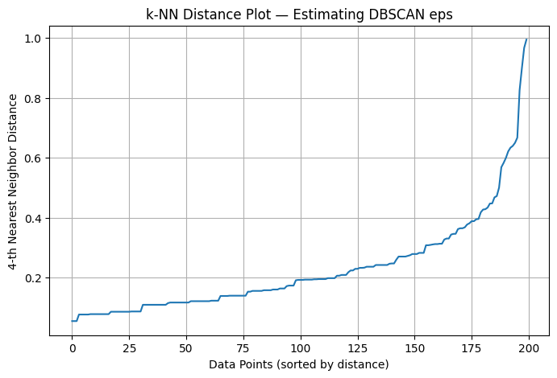

```python
# 5.1: Parameter tuning — epsilon
n_neighbors = 4
neighbors = NearestNeighbors(n_neighbors=n_neighbors)
neighbors.fit(df_2f)
distances, indices = neighbors.kneighbors(df_2f)

# The k-th nearest neighbor distance is the distance to the n_neighbors-th neighbor
# distances is (n_samples, n_neighbors). The last column is the k-th distance.
k_distances = distances[:, n_neighbors - 1]

# Sort the distances
sorted_k_distances = np.sort(k_distances)

# Plot
plt.figure(figsize=(8, 5))
plt.plot(sorted_k_distances)
plt.title('k-NN Distance Plot — Estimating DBSCAN eps')
plt.xlabel('Data Points (sorted by distance)')
plt.ylabel(f'{n_neighbors}-th Nearest Neighbor Distance')
plt.grid(True)
plt.show()
```

```python
# 5.2: Grid search eps & min_samples
eps_values = [0.2, 0.3, 0.4, 0.5, 0.6]
min_samples_values = [3, 4, 5, 6]

results = []

for eps in eps_values:
    for min_samples in min_samples_values:
        dbscan = DBSCAN(eps=eps, min_samples=min_samples)
        labels = dbscan.fit_predict(df_2f)

        n_clusters = len(set(labels)) - (1 if -1 in labels else 0)
        n_noise = list(labels).count(-1)

        # Calculate silhouette score only if there is more than 1 cluster and not all are noise
        if n_clusters > 1:
            # Exclude noise points from silhouette score calculation
            mask = labels != -1
            if np.sum(mask) > n_clusters:
                score = silhouette_score(df_2f[mask], labels[mask])
            else:
                score = -1 # Not enough points to calculate score
        else:
            score = -1

        results.append({
            'eps': eps,
            'min_samples': min_samples,
            'n_clusters': n_clusters,
            'n_noise': n_noise,
            'silhouette_score': score
        })

results_df = pd.DataFrame(results)
display(results_df)
```

<style scoped> .dataframe tbody tr th:only-of-type { vertical-align: middle; } .dataframe tbody tr th { vertical-align: top; } .dataframe thead th { text-align: right; } </style> <thead> <th></th> <th>eps</th> <th>min_samples</th> <th>n_clusters</th> <th>n_noise</th> <th>silhouette_score</th> </thead> <tbody> <th>0</th> <th>1</th> <th>2</th> <th>3</th> <th>4</th> <th>5</th> <th>6</th> <th>7</th> <th>8</th> <th>9</th> <th>10</th> <th>11</th> <th>12</th> <th>13</th> <th>14</th> <th>15</th> <th>16</th> <th>17</th> <th>18</th> <th>19</th> </tbody>

| 0.2 | 3 | 13 | 44 | 0.469713 |
| --- | --- | --- | --- | --- |
| 0.2 | 4 | 5 | 73 | 0.617282 |
| 0.2 | 5 | 7 | 77 | 0.585613 |
| 0.2 | 6 | 4 | 95 | 0.613836 |
| 0.3 | 3 | 9 | 14 | 0.472040 |
| 0.3 | 4 | 8 | 23 | 0.519746 |
| 0.3 | 5 | 7 | 35 | 0.524328 |
| 0.3 | 6 | 6 | 48 | 0.530244 |
| 0.4 | 3 | 4 | 10 | 0.395381 |
| 0.4 | 4 | 3 | 14 | 0.457570 |
| 0.4 | 5 | 4 | 15 | 0.478059 |
| 0.4 | 6 | 4 | 19 | 0.490015 |
| 0.5 | 3 | 2 | 7 | 0.389247 |
| 0.5 | 4 | 2 | 8 | 0.387558 |
| 0.5 | 5 | 2 | 8 | 0.387558 |
| 0.5 | 6 | 2 | 11 | 0.401149 |
| 0.6 | 3 | 1 | 0 | -1.000000 |
| 0.6 | 4 | 1 | 5 | -1.000000 |
| 0.6 | 5 | 1 | 5 | -1.000000 |
| 0.6 | 6 | 1 | 6 | -1.000000 |

```python
# 5.3: Fit final DBSCAN model
chosen_eps = 0.4
chosen_min_samples = 6

dbscan_final = DBSCAN(eps=chosen_eps, min_samples=chosen_min_samples)
dbscan_labels = dbscan_final.fit_predict(df_2f)

# Add labels to the original df
df['DBSCAN_Cluster'] = dbscan_labels
```

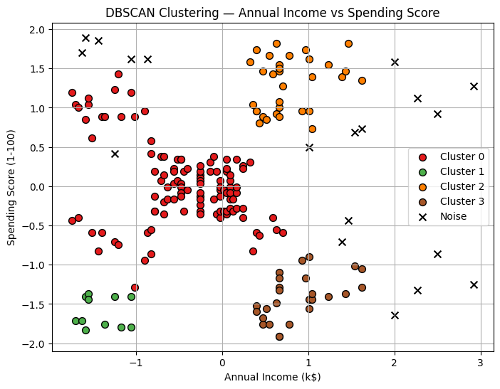

```python
# 5.4: Visualise DBSCAN clusters
plt.figure(figsize=(8, 6))

# Plotting points
# We use a colormap that can handle -1 (noise)
unique_labels = set(dbscan_labels)
colors = plt.get_cmap('Set1')(np.linspace(0, 1, len(unique_labels)))

for i, k in enumerate(unique_labels):
    if k == -1:
        # Black for noise
        col = (0, 0, 0, 1)
        marker = 'x'
        label = 'Noise'
    else:
        col = colors[i]
        marker = 'o'
        label = f'Cluster {k}'

    class_member_mask = (dbscan_labels == k)
    xy = df_2f[class_member_mask]
    if marker == 'x':
        plt.scatter(xy.iloc[:, 0], xy.iloc[:, 1], color=col, marker=marker, label=label, s=50)
    else:
        plt.scatter(xy.iloc[:, 0], xy.iloc[:, 1], color=col, marker=marker, label=label, edgecolors='k', s=50)

plt.title('DBSCAN Clustering — Annual Income vs Spending Score')
plt.xlabel('Annual Income (k$)')
plt.ylabel('Spending Score (1-100)')
plt.legend(loc='best')
plt.grid(True)
plt.show()
```

<h4 id="Understanding-DBSCAN-Parameters">**Understanding DBSCAN Parameters**</h4>

- **`eps` (Epsilon):** This parameter defines the maximum distance between two samples for one to be considered as in the neighborhood of the other. It effectively defines the "radius" of a neighborhood. If `eps` is too small, most data will be labeled as noise; if it's too large, clusters will merge.
- **`min_samples`:** The number of samples in a neighborhood for a point to be considered as a core point. This includes the point itself. A higher `min_samples` makes the algorithm more robust to noise but requires denser regions to form clusters.
- **Noise Points:** In DBSCAN, a point is labeled as noise if it is not a core point (doesn't have enough neighbors within `eps`) and is not reachable from any core point. These are points located in low-density regions that do not belong to any cluster.

<hr />

<h3 id="Task-6:-Algorithm-Comparison-&-Business-Insights">**Task 6: Algorithm Comparison & Business Insights**</h3> <thead> <th>#</th> <th>Action</th> <th>Details / Configuration</th> </thead> <tbody> </tbody>

[output not shown]

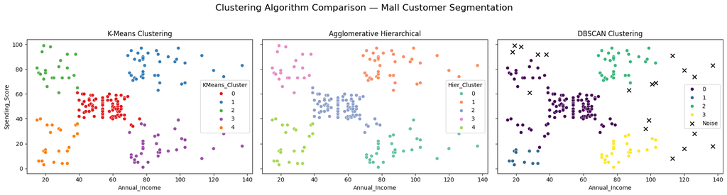

```python
# 6.1: Three-panel comparison figure
fig, axes = plt.subplots(1, 3, figsize=(18, 5), sharex=True, sharey=True)

# Panel 1: K-Means
sns.scatterplot(x='Annual_Income', y='Spending_Score', hue='KMeans_Cluster', data=df, palette='Set1', ax=axes[0])
axes[0].set_title('K-Means Clustering')

# Panel 2: Hierarchical
sns.scatterplot(x='Annual_Income', y='Spending_Score', hue='Hier_Cluster', data=df, palette='Set2', ax=axes[1])
axes[1].set_title('Agglomerative Hierarchical')

# Panel 3: DBSCAN
# Handle noise for DBSCAN manually for better visualization
ax3 = axes[2]
noise_mask = df['DBSCAN_Cluster'] == -1
cluster_mask = df['DBSCAN_Cluster'] != -1

# Plot clusters
sns.scatterplot(x='Annual_Income', y='Spending_Score', hue='DBSCAN_Cluster', data=df[cluster_mask], palette='viridis', ax=ax3)
# Plot noise
ax3.scatter(df[noise_mask]['Annual_Income'], df[noise_mask]['Spending_Score'], color='black', marker='x', label='Noise', s=50)

ax3.set_title('DBSCAN Clustering')
ax3.legend(loc='best')

plt.suptitle('Clustering Algorithm Comparison — Mall Customer Segmentation', fontsize=16)
plt.tight_layout(rect=[0, 0.03, 1, 0.95])
plt.show()
```

```python
# 6.2: Metrics summary table
from sklearn.metrics import silhouette_score

# Calculate metrics
# K-Means
km_labels = df['KMeans_Cluster']
km_k = len(np.unique(km_labels))
km_sil = silhouette_score(df_2f, km_labels)

# Hierarchical
hier_labels = df['Hier_Cluster']
hier_k = len(np.unique(hier_labels))
hier_sil = silhouette_score(df_2f, hier_labels)

# DBSCAN
dbscan_labels = df['DBSCAN_Cluster']
dbscan_k = len(np.unique(dbscan_labels[dbscan_labels != -1]))
mask = dbscan_labels != -1
dbscan_sil = silhouette_score(df_2f[mask], dbscan_labels[mask])

# Summary DataFrame
metrics_data = {
    'Algorithm': ['K-Means', 'Hierarchical', 'DBSCAN'],
    'n_clusters': [km_k, hier_k, dbscan_k],
    'Silhouette Score': [km_sil, hier_sil, dbscan_sil]
}
metrics_df = pd.DataFrame(metrics_data)
display(metrics_df)

print("\nNote: For DBSCAN, noise points are excluded from the silhouette score calculation.")
```

<style scoped> .dataframe tbody tr th:only-of-type { vertical-align: middle; } .dataframe tbody tr th { vertical-align: top; } .dataframe thead th { text-align: right; } </style> <thead> <th></th> <th>Algorithm</th> <th>n_clusters</th> <th>Silhouette Score</th> </thead> <tbody> <th>0</th> <th>1</th> <th>2</th> </tbody>

| K-Means | 5 | 0.554657 |
| --- | --- | --- |
| Hierarchical | 5 | 0.553809 |
| DBSCAN | 4 | 0.490015 |

```
Note: For DBSCAN, noise points are excluded from the silhouette score calculation.
```

<h3 id="Business-Insights-for-Mall-Management">**Business Insights for Mall Management**</h3><h4 id="Customer-Segment-Profiles-(K-Means)">**Customer Segment Profiles (K-Means)**</h4><p>Based on our clustering analysis, we have identified the following key customer segments:</p>

1. **High Income, High Spenders (Target Segment):** These are your most valuable customers. They have high purchasing power and high engagement.
2. **Low Income, High Spenders (Trendsetters):** Younger or impulse-driven customers who spend a lot despite lower income.
3. **Middle Income, Middle Spenders (Stable Segment):** The core customer base, providing steady and predictable revenue.
4. **High Income, Low Spenders (Potential Growth):** Wealthy individuals who aren't spending much at the mall. They represent a significant opportunity for upselling.
5. **Low Income, Low Spenders (Budget-Conscious):** Price-sensitive shoppers who primarily focus on essentials.

<h4 id="Targeted-Marketing-Recommendations">**Targeted Marketing Recommendations**</h4> <thead> <th style="text-align:left">Segment</th> <th style="text-align:left">Recommended Marketing Action</th> </thead> <tbody> </tbody>

| **High Income, High Spenders** | **Exclusive Loyalty Programs:** Offer VIP access, personal shopping assistants, and early access to premium collections. |
| --- | --- |
| **Low Income, High Spenders** | **Trend-Driven Social Campaigns:** Use influencers and social media to highlight "must-have" items and flash sales. |
| **Middle Income, Middle Spenders** | **Value-Added Promotions:** Implement seasonal discounts and bundle offers to increase basket size and frequency. |
| **High Income, Low Spenders** | **Personalized High-Value Offers:** Use direct mail or premium email campaigns featuring luxury brands and concierge services. |
| **Low Income, Low Spenders** | **Discount & Essential Focus:** Highlight budget-friendly options, couponing, and essential goods via mass-market channels. |

<h4 id="Algorithm-Recommendation">**Algorithm Recommendation**</h4><p>**Recommended for Deployment: K-Means Clustering**</p> <p>**Why?** While each algorithm provides valuable insights, **K-Means** is the most practical choice for immediate deployment in a mall management setting for several reasons:</p>

- **Interpretability:** K-Means produces clear, centroid-based segments that are easy to explain to non-technical stakeholders (e.g., "The average person in this group earns X and spends Y").
- **Operational Ease:** It is computationally efficient and easy to assign new customers to existing segments as soon as their data is collected.
- **Segment Stability:** It provides stable, well-defined boundaries for the primary customer profiles that marketing teams can act upon.

<p>**When to use others:**</p>

- Use **Hierarchical Clustering** when you need to understand the granular relationship between segments (e.g., seeing how "High Income" splits into "High Spenders" and "Low Spenders").
- Use **DBSCAN** if you suspect the existence of complex, non-spherical customer patterns or if you need to robustly identify and ignore outlier behaviors.

<hr />